# 📈 Financial Data Visualization (TSLA, AAPL, S&P 500, BTC, Gold)

This notebook downloads and visualizes stock/asset price data for:

- Tesla (TSLA)
- Apple (AAPL)
- S&P 500 (^GSPC)
- Bitcoin (BTC-USD)
- Gold (GC=F)

## 🔄 Download Data

Using Yahoo Finance API via `yfinance`, we’ll download the past year of data.

## 📈 1. Line Plot of Closing Prices

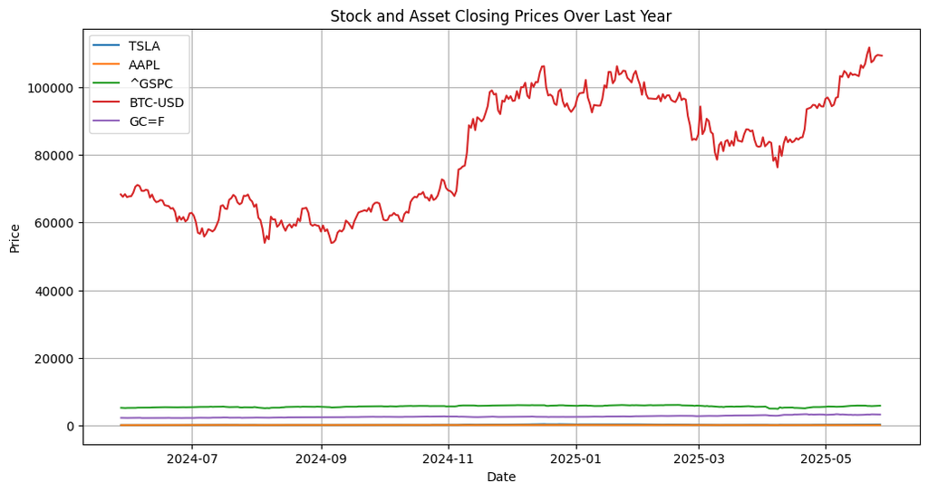

## 📈 Normalized Plot of Closing Prices

Since the absolute price ranges differ greatly (e.g., BTC vs. TSLA), we normalize prices by dividing each by its initial value. This allows for comparing relative performance over time.

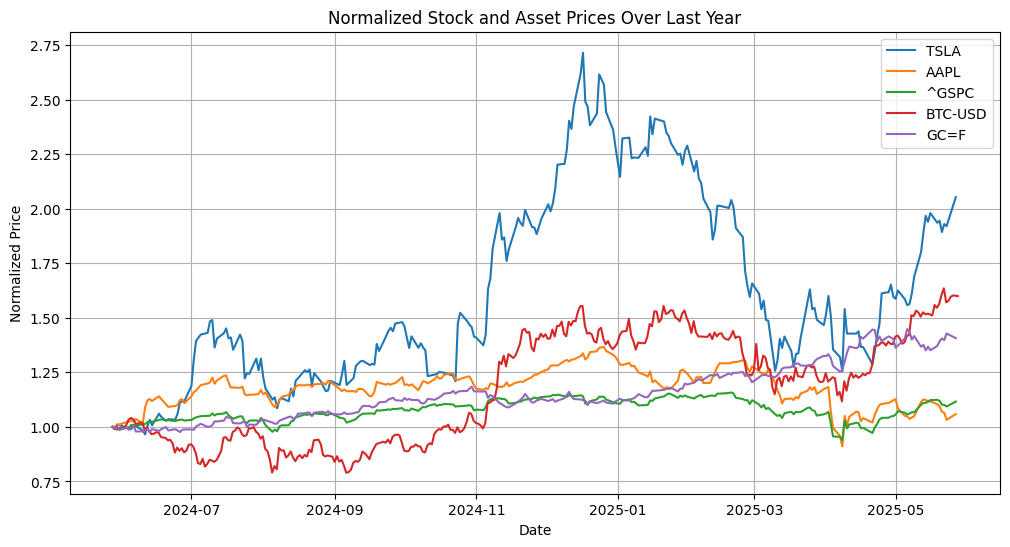

## 📈 Histogram of Daily Returns

We calculate daily returns as the percentage change of closing prices and plot their distribution for each symbol.

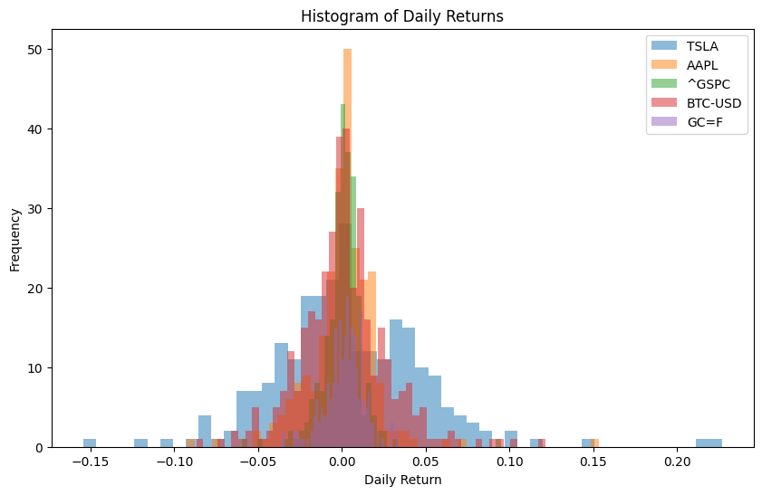

## 📦 Box Plot of Daily Returns

We calculate daily returns for each symbol and create a box plot to show their distribution and outliers.

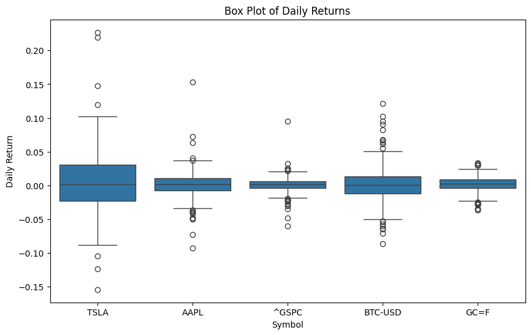

## 🔥 Correlation Heatmap of Weekly Returns

This improved version resamples data to weekly frequency and uses forward filling to reduce missing data issues. It removes rows with no valid data across all symbols, providing a clearer and more complete correlation matrix.

```
Missing values per column before cleaning:
TSLA       54
AAPL       54
^GSPC      54
BTC-USD    54
GC=F       54
dtype: int64
Shape of cleaned DataFrame: (104, 5)
Correlation matrix calculated:
             TSLA      AAPL     ^GSPC   BTC-USD      GC=F
TSLA     1.000000  0.460103  0.553573  0.219870  0.020601
AAPL     0.460103  1.000000  0.662231 -0.027865 -0.011178
^GSPC    0.553573  0.662231  1.000000  0.223232  0.080658
BTC-USD  0.219870 -0.027865  0.223232  1.000000  0.023512
GC=F     0.020601 -0.011178  0.080658  0.023512  1.000000
```

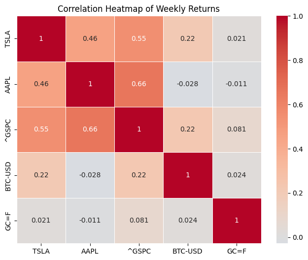

## 🔍 6. Scatter Plots of Weekly Returns

Scatter plots are great for visualizing how two assets' returns relate to each other.

```
Weekly returns shape: (104, 5)
```

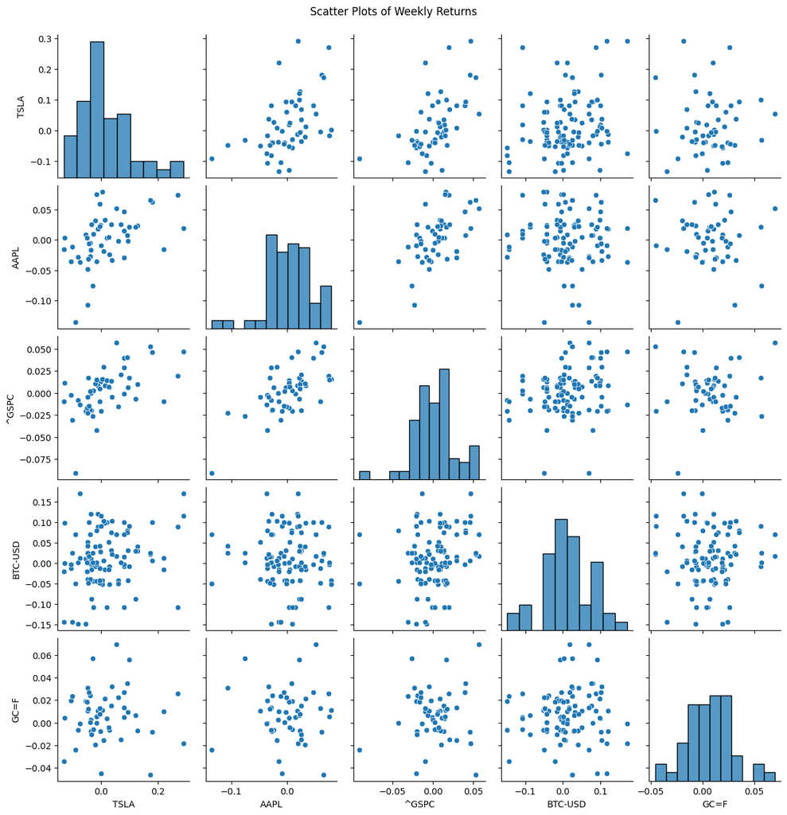

## 📈 7. Moving Averages (20-week, 50-week)

A moving average smooths out price data to show trends.

- **20-week moving average (MA20)** is the average closing price over the past 20 weeks.
- **50-week moving average (MA50)** does the same for 50 weeks.  
  When the short-term average (MA20) crosses above the long-term (MA50), it can indicate a bullish trend, and vice versa.  
  This helps traders spot long-term market direction.

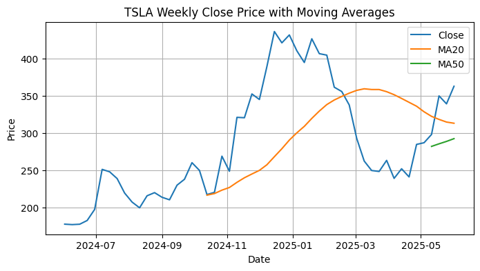

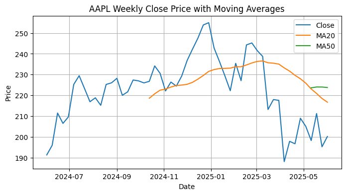

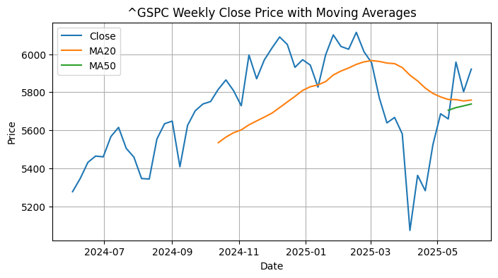

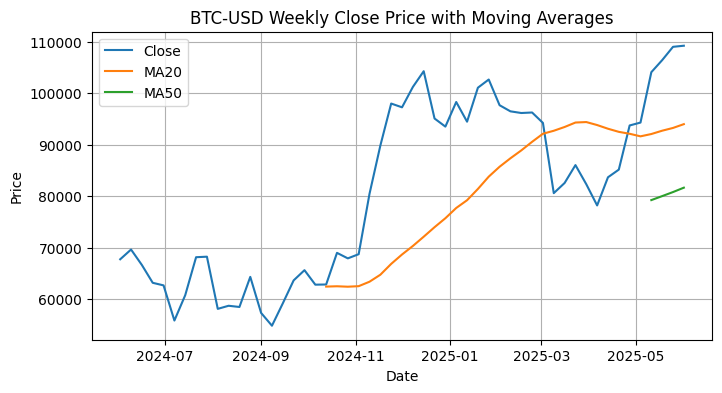

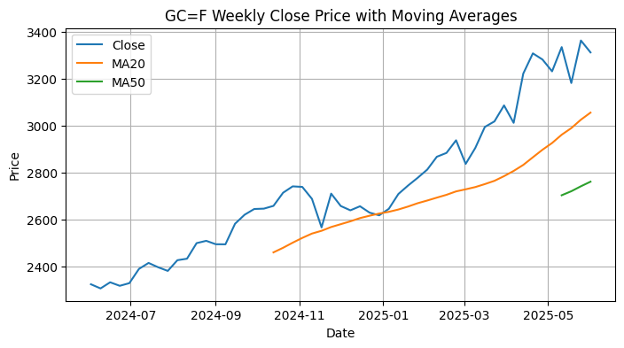

## 📊 8. Weekly Trading Volume

Trading volume shows how much of an asset was traded in a week.

- High volume can indicate strong interest and liquidity.
- Low volume can indicate weak interest or illiquidity.  
  This is important because volume often accompanies big price moves or reversals.

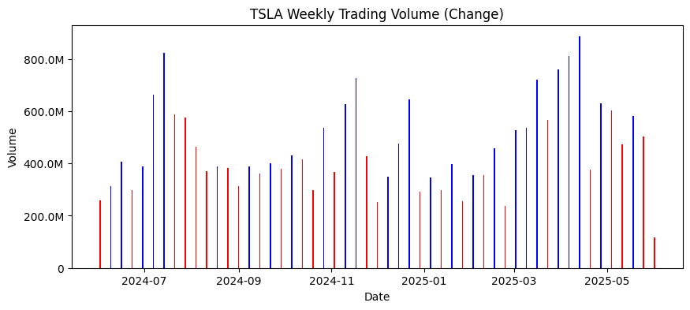

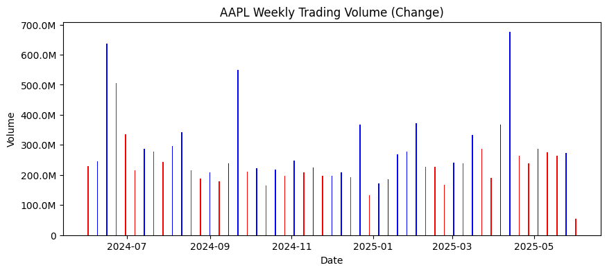

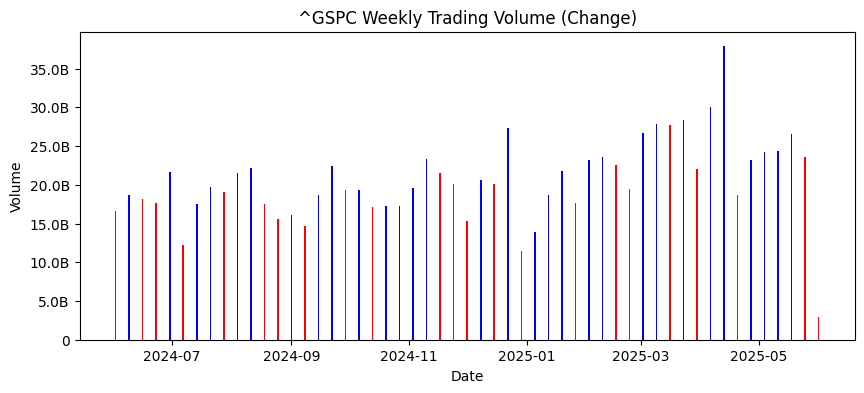

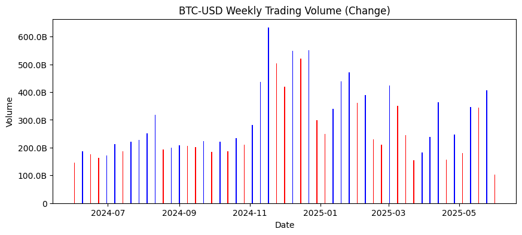

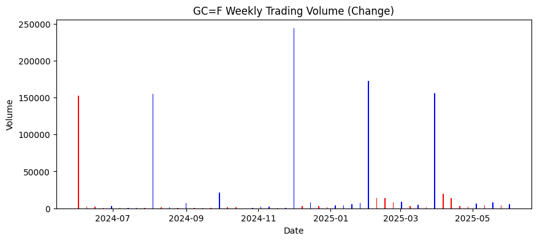

## 🌊 9. 20-Week Rolling Volatility

Volatility shows how much the price returns vary (how risky the asset is).

- **High volatility** means the price changes a lot; it’s riskier.
- **Low volatility** means the price is stable.  
  We use a rolling window of 20 weeks to measure the standard deviation of returns.  
  This shows how volatility changes over time, which helps with risk assessment.

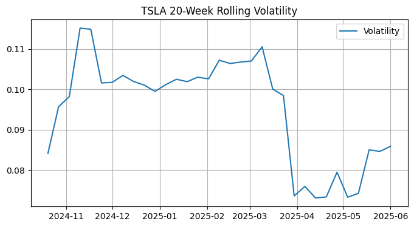

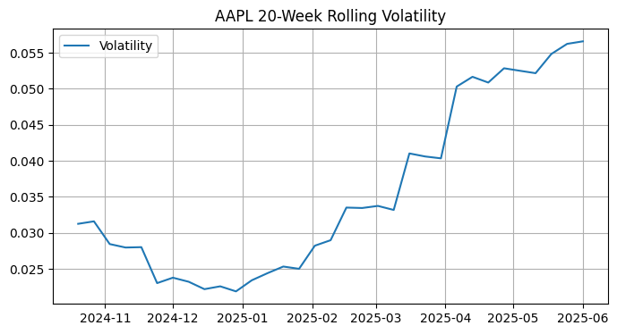

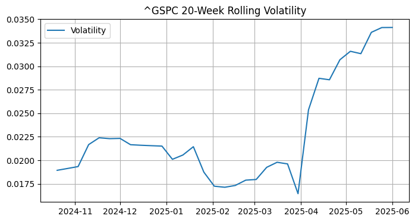

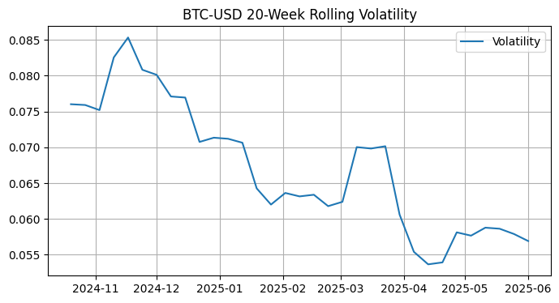

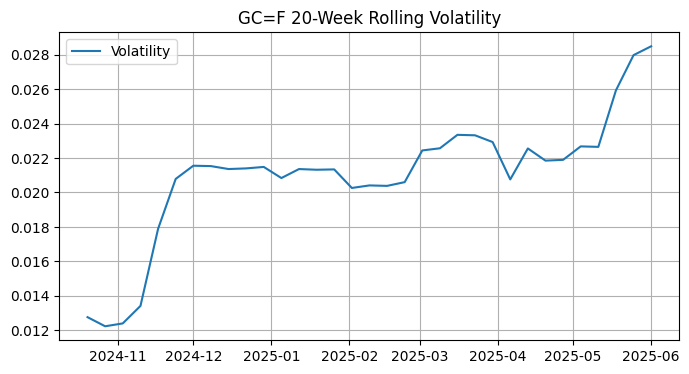